#### Dragos Ailoae

2022-03-31

# Intro to Binary Choice Models

The "Mroz" dataset contains cross-sectional labor force participation data. For more information see Mroz, T. (1987) *“The sensitivity of an empirical model of married women's hours of work to economic and statistical assumptions”, Econometrica, 55, 765-799.* Additional documentation available [here](https://vincentarelbundock.github.io/Rdatasets/doc/Ecdat/Mroz.html)

- **inlf - =1 if in labor force, 1975**
- hours- hours worked, 1975
- kidslt6- # kids < 6 years
- kidsge6- # kids 6-18
- age- woman’s age in yrs
- educ- years of schooling
- wage- estimated wage from earns., hours
- repwage- reported wage at interview in 1976
- hushrs- hours worked by husband, 1975
- husage- husband’s age
- huseduc- husband’s years of schooling
- huswage- husband’s hourly wage, 1975
- faminc- family income, 1975
- mtr - fed. marginal tax rate facing woman
- motheduc- mother’s years of schooling
- fatheduc- father’s years of schooling
- unem- unem. rate in county of resid.
- city- =1 if live in SMSA
- exper- actual labor mkt exper
- nwifeinc- (faminc - wage*hours)/1000
- lwage- log(wage)
- expersq - exper^2

We are interested in modeling the labor force participation, inlf, of married women.

```r
rm(list=ls())    # Removes all items in Environment!
#
# OPTIONS:
options(warn=-1) # Suppress warnings
options(repr.plot.width = 6, repr.plot.height = 6)
#
# LOAD PACKAGES:
packages <- c("foreign","tidyverse","modelsummary")
# Loop though vector and load respective packages with options:
#zzz <- lapply(packages, require, character.only = TRUE) # verbose
# quiet
zzz <- lapply(packages, function(xxx) suppressMessages(require(xxx,
               character.only = TRUE, quietly=TRUE, warn.conflicts = FALSE)))
```

```r
raw.data <- read.dta("http://fmwww.bc.edu/ec-p/data/wooldridge/mroz.dta")
my.df <- data.frame(raw.data)
datasummary_skim(my.df) %>% as.character %>% IRdisplay::display_html()
```

Unique (#)

Missing (%)

Mean

SD

Min

Median

Max

inlf

2

0

0.6

0.5

0.0

1.0

1.0

hours

306

0

740.6

871.3

0.0

288.0

4950.0

kidslt6

4

0

0.2

0.5

0.0

0.0

3.0

[figure not shown]

kidsge6

9

0

1.4

1.3

0.0

1.0

8.0

age

31

0

42.5

8.1

30.0

43.0

60.0

[figure not shown]

educ

13

0

12.3

2.3

5.0

12.0

17.0

wage

374

43

4.2

3.3

0.1

3.5

25.0

repwage

164

0

1.8

2.4

0.0

0.0

10.0

hushrs

422

0

2267.3

595.6

175.0

2164.0

5010.0

husage

31

0

45.1

8.1

30.0

46.0

60.0

[figure not shown]

huseduc

15

0

12.5

3.0

3.0

12.0

17.0

[figure not shown]

huswage

697

0

7.5

4.2

0.4

7.0

40.5

faminc

613

0

23080.6

12190.2

1500.0

20880.0

96000.0

mtr

22

0

0.7

0.1

0.4

0.7

0.9

motheduc

9

0

9.3

3.4

0.0

10.0

17.0

fatheduc

9

0

8.8

3.6

0.0

7.0

17.0

unem

7

0

8.6

3.1

3.0

7.5

14.0

city

2

0

0.6

0.5

0.0

1.0

1.0

exper

40

0

10.6

8.1

0.0

9.0

45.0

nwifeinc

686

0

20.1

11.6

−0.0

17.7

96.0

lwage

374

43

1.2

0.7

−2.1

1.2

3.2

expersq

40

0

178.0

249.6

0.0

81.0

2025.0

To familiarize ourselves with the data let's look at how the dependent variable relates to the explanatory variables.

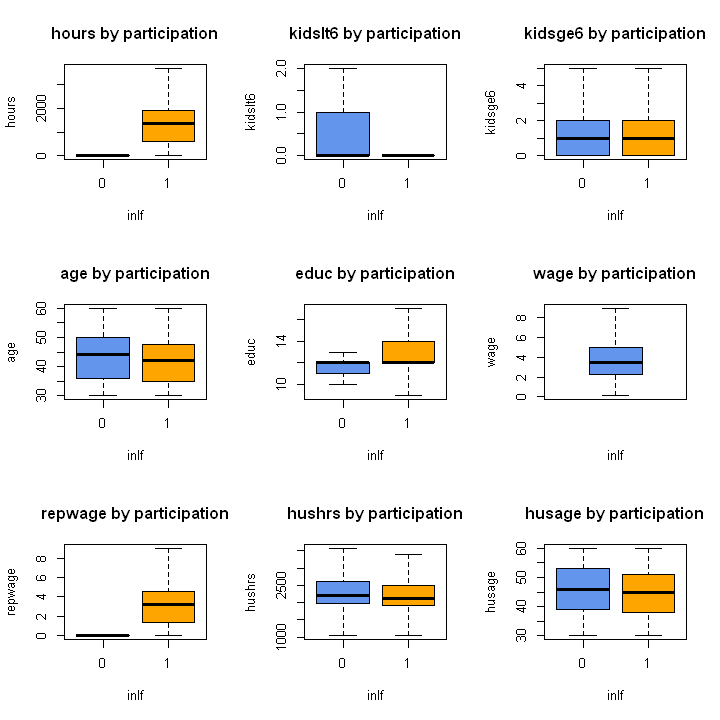

```r
iter_cols = colnames(my.df)[1:22]
#
par(mfrow = c(3, 3))
for(i in 2:10){
    tmp_formula <- formula(paste0(iter_cols[i]," ~ inlf"))
    boxplot(tmp_formula, my.df,
            col = c("cornflowerblue", "orange"),
            xlab = "inlf", ylab = colnames(my.df)[i], outline = FALSE,
            main = paste0(colnames(my.df)[i], " by participation"))
}
```

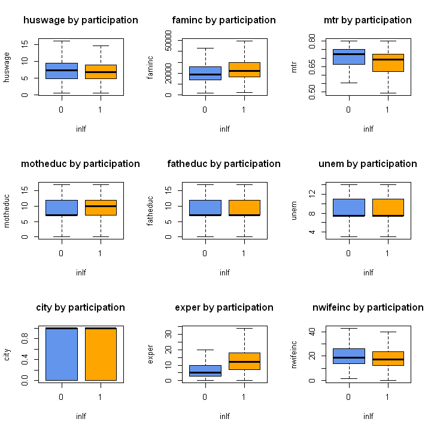

```r
par(mfrow = c(3, 3))
for(i in 12:20){
    tmp_formula <- formula(paste0(iter_cols[i]," ~ inlf"))
    boxplot(tmp_formula, my.df,
            col = c("cornflowerblue", "orange"),
            xlab = "inlf", ylab = colnames(my.df)[i], outline = FALSE,
            main = paste0(colnames(my.df)[i], " by participation"))
}
```

### The Linear Probability Model (LPM)

The linear regression model $$ Y_{i}=\beta_{0}+\beta_{1} X_{1 i}+\beta_{2} X_{2 i}+\cdots+\beta_{k} X_{k i}+u_{i} $$ with a binary dependent variable $Y_{i}$ is called the linear probability model. In the linear probability model we have $$ E\left(Y \mid X_{1}, X_{2}, \ldots, X_{k}\right)=P\left(Y=1 \mid X_{1}, X_{2}, \ldots, X_{3}\right) $$ where $$ P\left(Y=1 \mid X_{1}, X_{2}, \ldots, X_{k}\right)=\beta_{0}+\beta_{1}+X_{1 i}+\beta_{2} X_{2 i}+\cdots+\beta_{k} X_{k i} $$ Thus, $\beta_{j}$ can be interpreted as the change in the probability that $Y_{i}=1$, holding constant the other $k-1$ regressors. Just as in common multiple regression, the $\beta_{j}$ can be estimated using OLS and the robust standard error formulas can be used for hypothesis testing and computation of confidence intervals.

In most linear probability models, $R^{2}$ has no meaningful interpretation since the regression line can never fit the data perfectly if the dependent variable is binary and the regressors are continuous. This can be seen in the application below.

It is essential to use **robust standard errors** (or use FGLS) since the $u_{i}$ in a linear probability model are always heteroskedastic. To understand this consider $Y_{i}$ as a Bernoulli random variable, denoted $Y_{i} \sim \operatorname{Bern}\left(p_{i}\right)$, where: $$ Y_{i}=\left\{\begin{array}{l} 1, \text { with probability } p_{i} \\ 0, \text { with probability } 1-p_{i} \end{array}\right. $$ which we can also write as $\mathbb{P}\left(Y_{i}=1\right)=p_{i}$ and $\mathbb{P}\left(Y_{i}=0\right)=1-\mathbb{P}\left(Y_{i}=1\right)=1-p_{i}$, or more compactly as: $$ \mathbb{P}\left(Y_{i}=y_{i}\right)=p_{i}^{y_{i}}\left(1-p_{i}\right)^{1-y_{i}}, \quad y_{i} \in\{0,1\} $$ It can be verified that: $$ \begin{aligned} \mathbb{E}\left(Y_{i}\right) &=\mu_{i}=p_{i} \\ \mathbb{V a r}\left(Y_{i}\right) &=\sigma_{i}^{2}=p_{i}\left(1-p_{i}\right) \end{aligned} $$ Since both the mean and variance of the process depend on $p_{i}$ - any factors that have an effect on $p_{i}$ will effect not only the process mean, but the variance of $Y_{i}$ (i.e. the variance is not constant, hence heteroskedasticity is present in the data).

```r
equation <- inlf ~ nwifeinc + educ + exper + expersq + age + kidslt6 + kidsge6
LPM <- lm(equation, data = my.df)
modelsummary(LPM, title ="LPM with Classical / Robust / Stata / HC4 Standard Errors",
             vcov = c("classical", "robust", "stata", "HC4"),  # "stata" SEs are equivalent to HC1 in R
             fmt = "%.4f",stars = TRUE
            ) %>% as.character %>% IRdisplay::display_html()
```

LPM with Classical / Robust / Stata / HC4 Standard Errors

|  | Model 1 | Model 2 | Model 3 | Model 4 |
| --- | --- | --- | --- | --- |
| (Intercept) | 0.5855*** | 0.5855*** | 0.5855*** | 0.5855*** |
|  | (0.1542) | (0.1536) | (0.1523) | (0.1534) |
| nwifeinc | −0.0034* | −0.0034* | −0.0034* | −0.0034* |
|  | (0.0014) | (0.0016) | (0.0015) | (0.0016) |
| educ | 0.0380*** | 0.0380*** | 0.0380*** | 0.0380*** |
|  | (0.0074) | (0.0073) | (0.0073) | (0.0073) |
| exper | 0.0395*** | 0.0395*** | 0.0395*** | 0.0395*** |
|  | (0.0057) | (0.0060) | (0.0058) | (0.0062) |
| expersq | −0.0006** | −0.0006** | −0.0006** | −0.0006** |
|  | (0.0002) | (0.0002) | (0.0002) | (0.0002) |
| age | −0.0161*** | −0.0161*** | −0.0161*** | −0.0161*** |
|  | (0.0025) | (0.0024) | (0.0024) | (0.0024) |
| kidslt6 | −0.2618*** | −0.2618*** | −0.2618*** | −0.2618*** |
|  | (0.0335) | (0.0322) | (0.0318) | (0.0322) |
| kidsge6 | 0.0130 | 0.0130 | 0.0130 | 0.0130 |
|  | (0.0132) | (0.0137) | (0.0135) | (0.0136) |
| Num.Obs. | 753 | 753 | 753 | 753 |
| R2 | 0.264 | 0.264 | 0.264 | 0.264 |
| R2 Adj. | 0.257 | 0.257 | 0.257 | 0.257 |
| AIC | 865.8 | 865.8 | 865.8 | 865.8 |
| BIC | 907.4 | 907.4 | 907.4 | 907.4 |
| Log.Lik. | −423.892 | −423.892 | −423.892 | −423.892 |
| F | 38.218 | 61.350 | 62.481 | 61.284 |
| Std.Errors | Classical | Robust | Stata | HC4 |

+ p < 0.1, * p < 0.05, ** p < 0.01, *** p < 0.001

Compare this to the Stata output in the lecture slides (note that output shows Stata classical standard errors NOT robust)

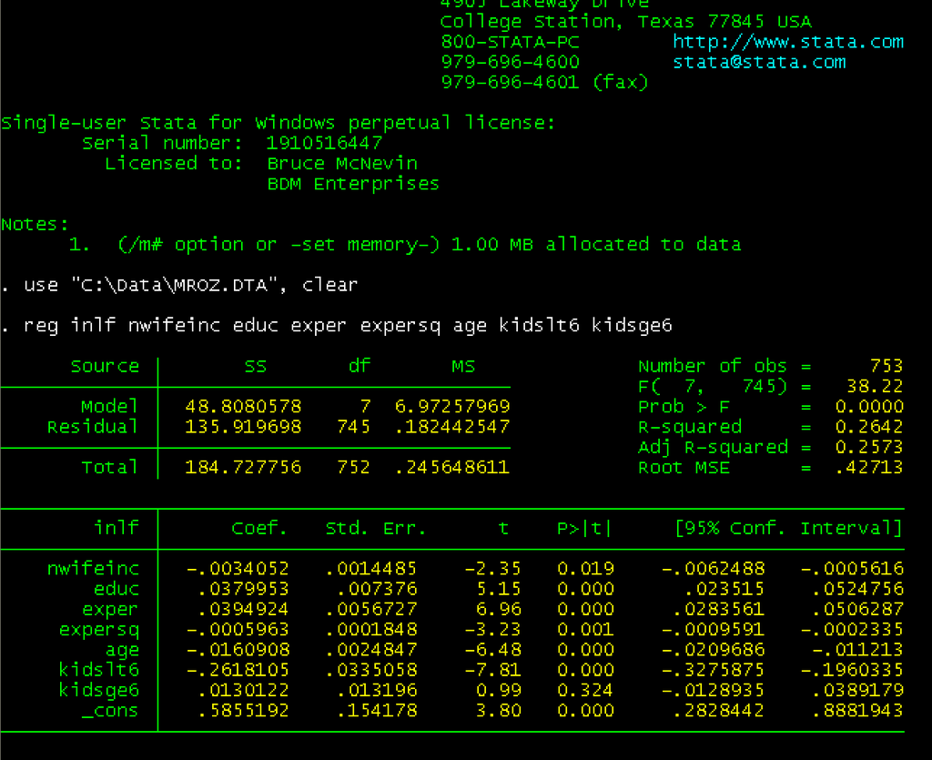

#### Coefficients Interpretation

- The signs of the coefficient estimates are sensible, and with the exception of the variable for (number of) children ages 6-18, all of the coefficients are statistically significant.
- The coefficient on non-wife income means that if income increases by $10(\$ 10,000)$, the probability of a women being in the work force decreases by 3.4 percent.
- Having one more child under the age of 6 reduces the probability of working by 26.2 percent.

### LPM deficiencies

The linear probability model has a major flaw: it assumes the conditional probability function to be linear. This does not restrict $P\left(Y=1 \mid X_{1}, \ldots, X_{k}\right)$ to lie between 0 and 1 . We can easily see that our LPM model predicts the probability of labor particiaption to be bigger than 1 . In certain cases, the predicted probability of working is even negative so that the model has no meaningful interpretation here.

```r
lpm.predict <- predict (LPM)
head(sort(lpm.predict,decreasing=TRUE),n=20)
tail(sort(lpm.predict,decreasing=TRUE),n=20)
```

**300**

1.12715052833919

**35**

1.08299537202369

**163**

1.07229998400096

**40**

1.05138578170014

**158**

1.0490010462202

**26**

1.03879447490448

**280**

1.03703973675465

**392**

1.03687685327081

**143**

1.03576882089877

**345**

1.03542640766909

**150**

1.03374272570116

**167**

1.02454705424294

**78**

1.01804716299707

**332**

1.01691365595641

**142**

1.01486728865259

**398**

1.00270904885578

**304**

1.00178573050614

**187**

0.99817367964098

**419**

0.988410314036276

**315**

0.978615545919981

**553**

0.0185608348063994

**641**

0.010692240940935

**580**

0.00707115298791768

**402**

0.00582975908775182

**485**

-0.00325312309313652

**621**

-0.0128441733639601

**640**

-0.0131462999631918

**593**

-0.0255591524770741

**487**

-0.0281297141887243

**514**

-0.037761683979287

**650**

-0.0856437792034057

**689**

-0.102660571750716

**562**

-0.114702090690979

**715**

-0.120588118272455

**596**

-0.152886475459291

**605**

-0.159633259977218

**586**

-0.163268979449373

**677**

-0.172159974284455

**484**

-0.329286052683359

**531**

-0.345110262113216

This circumstance calls for an approach that uses a nonlinear function to model the conditional probability function of a binary dependent variable. Commonly used methods are Probit and Logit regression.

### LPM vs. Probit/Logit: Rule of thumb

The major advantage of the LPM is its intuitive interpretation of the coefficients. Interpretation of Probit and Logic parameters is less intuitive (odds ratios, z-scores, local effects, etc.).

If the probabilities modeled are extreme — close to 0 or 1 — then you probably have to use logistic regression. But if the probabilities are more moderate — say between .20 and .80 - then the linear and logistic models fit about equally well, and the linear model should be favored for its ease of interpretation.

Consider a case where y is driven by a single X:

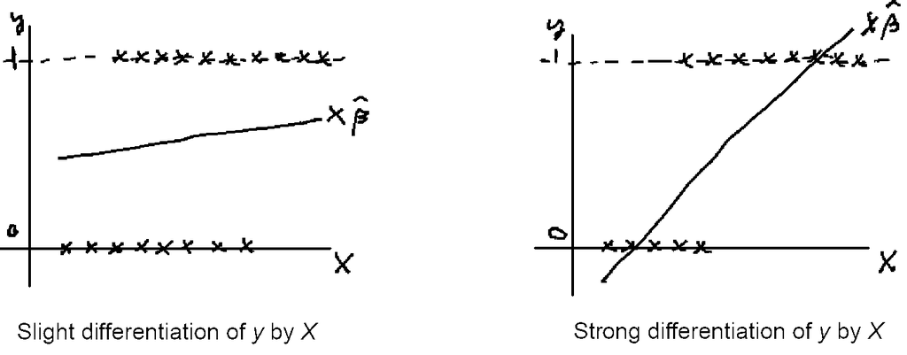

So LPM is more suitable for the case with slight differentiation.

Bottom line, if modeling the probability of participating in the labor force, voting, or of being overweight, then nearly all the modeled probabilities will be between .20 and .80, and a linear probability model should fit nicely and offer a straightforward interpretation. On the other hand, if modeling the probability that a bank transaction is fraudulent then the modeled probabilities typically range between .000001 and .20. In that situation, the linear model just isn’t viable, and a nonlinear model should be used.

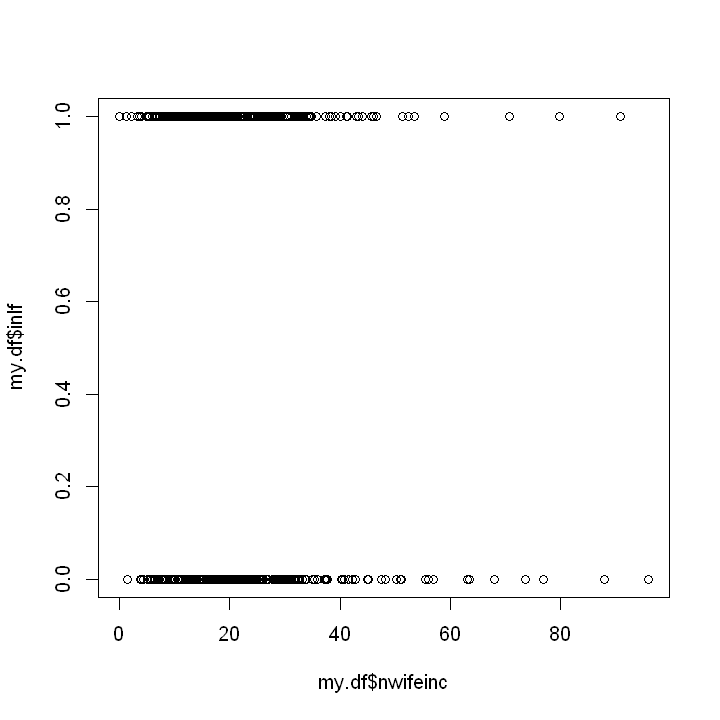

```r
plot(my.df$nwifeinc,my.df$inlf)
```

### Probit Model, Predicted Probabilities and Estimated Effects

Assume that $Y$ is a binary variable. The model $$ Y=\beta_{0}+\beta_{1}+X_{1}+\beta_{2} X_{2}+\cdots+\beta_{k} X_{k}+u $$ with $$ P\left(Y=1 \mid X_{1}, X_{2}, \ldots, X_{k}\right)=\Phi\left(\beta_{0}+\beta_{1}+X_{1}+\beta_{2} X_{2}+\cdots+\beta_{k} X_{k}\right) $$ is the population Probit model with multiple regressors $X_{1}, X_{2}, \ldots, X_{k}$ and $\Phi(\cdot)$ is the cumulative standard normal distribution function.

```r
probit_glm <- glm(equation, data = my.df, family = binomial(link = "probit"))
modelsummary(probit_glm, title ="Probit Model (MLE)",
             fmt = "%.4f",stars = TRUE
            ) %>% as.character %>% IRdisplay::display_html()
```

Probit Model (MLE)

|  | Model 1 |
| --- | --- |
| (Intercept) | 0.2701 |
|  | (0.5081) |
| nwifeinc | −0.0120* |
|  | (0.0049) |
| educ | 0.1309*** |
|  | (0.0254) |
| exper | 0.1233*** |
|  | (0.0188) |
| expersq | −0.0019** |
|  | (0.0006) |
| age | −0.0529*** |
|  | (0.0085) |
| kidslt6 | −0.8683*** |
|  | (0.1184) |
| kidsge6 | 0.0360 |
|  | (0.0440) |
| Num.Obs. | 753 |
| AIC | 818.6 |
| BIC | 855.6 |
| Log.Lik. | −401.302 |
| F | 25.501 |

+ p < 0.1, * p < 0.05, ** p < 0.01, *** p < 0.001

Compare this to the Stata output in the lecture slides:

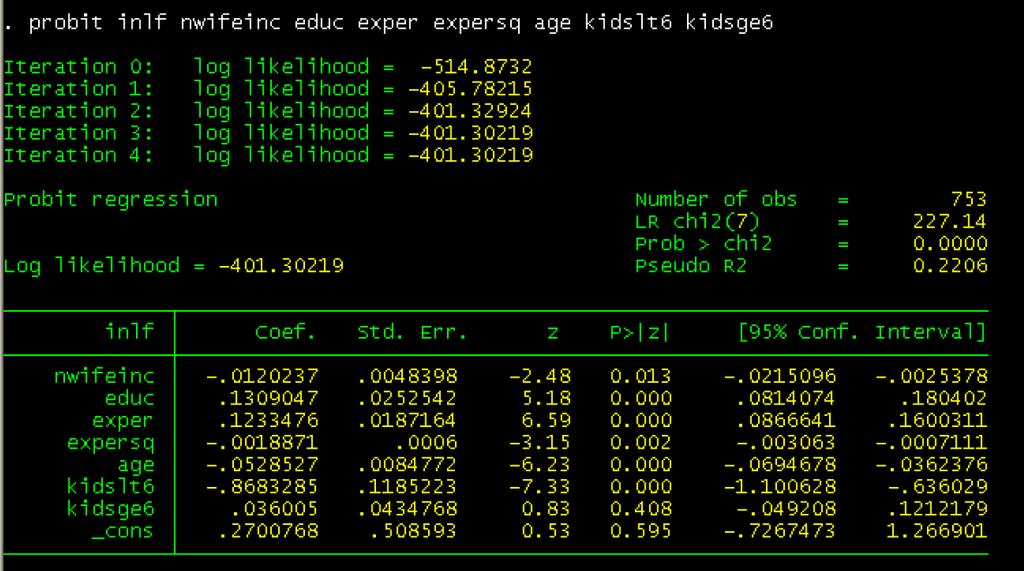

### Logit Regression

The population Logit regression function is $$ \begin{aligned} P\left(Y=1 \mid X_{1}, X_{2}, \ldots, X_{k}\right) &=F\left(\beta_{0}+\beta_{1} X_{1}+\beta_{2} X_{2}+\cdots+\beta_{k} X_{k}\right) \\ &=\frac{1}{1+e^{-\left(\beta_{0}+\beta_{1} X_{1}+\beta_{2} X_{2}+\cdots+\beta_{k} X_{k}\right)}} \end{aligned} $$ The idea is similar to Probit regression except that a different CDF is used: $$ F(x)=\frac{1}{1+e^{-x}} $$ is the CDF of a standard logistically distributed random variable.

```r
logit_glm <- glm(equation, data = my.df, family = binomial(link = "logit"))
modelsummary(logit_glm, title ="Logit Model",
             fmt = "%.4f",stars = TRUE
            ) %>% as.character %>% IRdisplay::display_html()
```

Logit Model

|  | Model 1 |
| --- | --- |
| (Intercept) | 0.4255 |
|  | (0.8604) |
| nwifeinc | −0.0213* |
|  | (0.0084) |
| educ | 0.2212*** |
|  | (0.0434) |
| exper | 0.2059*** |
|  | (0.0321) |
| expersq | −0.0032** |
|  | (0.0010) |
| age | −0.0880*** |
|  | (0.0146) |
| kidslt6 | −1.4434*** |
|  | (0.2036) |
| kidsge6 | 0.0601 |
|  | (0.0748) |
| Num.Obs. | 753 |
| AIC | 819.5 |
| BIC | 856.5 |
| Log.Lik. | −401.765 |
| F | 21.785 |

+ p < 0.1, * p < 0.05, ** p < 0.01, *** p < 0.001

Compare this to the Stata output in the lecture slides (note that output shows classical standard errors NOT robust)

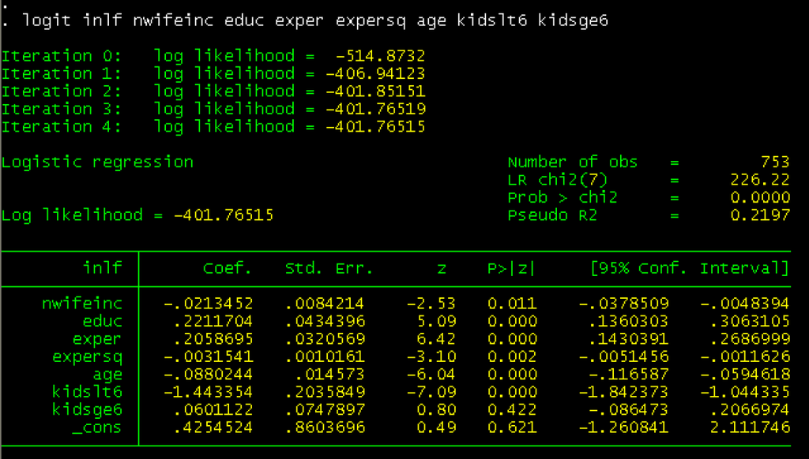

```r
models <- list(LPM = LPM, Probit = probit_glm, Logit = logit_glm)
modelsummary(models, title ="Labor force participation models",
             group = model ~ term,
             fmt = "%.4f",stars = TRUE,
             gof_omit = ".*") %>% as.character %>% IRdisplay::display_html()
```

Labor force participation models

|  | (Intercept) | nwifeinc | educ | exper | expersq | age | kidslt6 | kidsge6 |
| --- | --- | --- | --- | --- | --- | --- | --- | --- |
| LPM | 0.5855*** | −0.0034* | 0.0380*** | 0.0395*** | −0.0006** | −0.0161*** | −0.2618*** | 0.0130 |
|  | (0.1542) | (0.0014) | (0.0074) | (0.0057) | (0.0002) | (0.0025) | (0.0335) | (0.0132) |
| Probit | 0.2701 | −0.0120* | 0.1309*** | 0.1233*** | −0.0019** | −0.0529*** | −0.8683*** | 0.0360 |
|  | (0.5081) | (0.0049) | (0.0254) | (0.0188) | (0.0006) | (0.0085) | (0.1184) | (0.0440) |
| Logit | 0.4255 | −0.0213* | 0.2212*** | 0.2059*** | −0.0032** | −0.0880*** | −1.4434*** | 0.0601 |
|  | (0.8604) | (0.0084) | (0.0434) | (0.0321) | (0.0010) | (0.0146) | (0.2036) | (0.0748) |

+ p < 0.1, * p < 0.05, ** p < 0.01, *** p < 0.001

Comparing the three models we note very different coefficients (including a Logit coefficient of -1.44?!). We will dig into the interpretation of Logit and Probit coefficients next week.